# Chapter 6. Analysis of longitudinal data

## Standardising the dataset and plotting it again

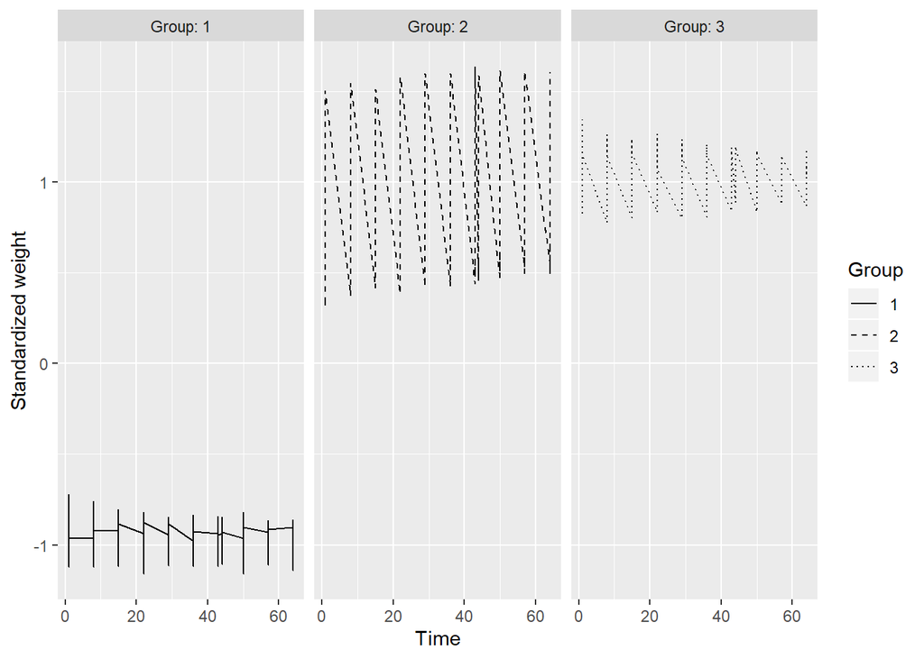

```r
library(ggplot2)
RATSL <- RATSL %>%
  group_by(WD) %>%
  mutate(stdrats = (Weight - mean(Weight))/sd(Weight) ) %>%
  ungroup()

ggplot(RATSL, aes(x = Time, y = stdrats, linetype = Group)) +
  geom_line() +
    scale_linetype_manual(values = rep(1:10, times=4)) +
  facet_grid(. ~ Group, labeller = label_both) +
  scale_y_continuous(name = "Standardized weight")
```

Tracking can be seen more clearly after standardization.

## Mean response profile

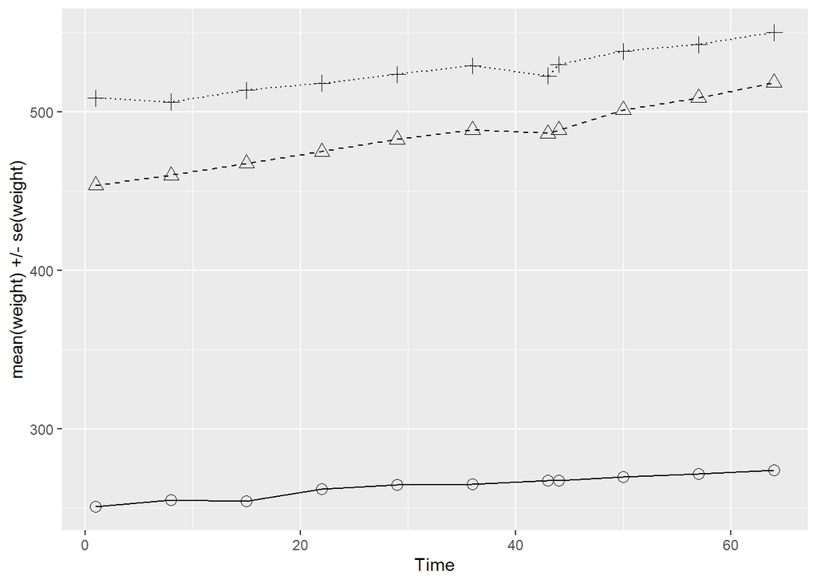

```r
library(dplyr)
library(tidyr)
library(ggplot2)
n <- RATSL$Time %>% unique() %>% length()
RATSS <- RATSL %>%
  group_by(Group, Time) %>%
  summarise( mean = mean(Weight), se = sd(Weight)/sqrt(n) ) %>%
  ungroup()

ggplot(RATSS, aes(x = Time, y = mean, linetype = Group, shape = Group)) +
  geom_line() +
  scale_linetype_manual(values = c(1,2,3)) +
  geom_point(size=3) +
  scale_shape_manual(values = c(1,2,3)) +
  theme(legend.position = c(0.8,0.8, 0.8)) +
  scale_y_continuous(name = "mean(weight) +/- se(weight)")
```

There is no overlap in the three intervention groups and there is a neat difference in their respective means.

## Boxplot of mean summary measure

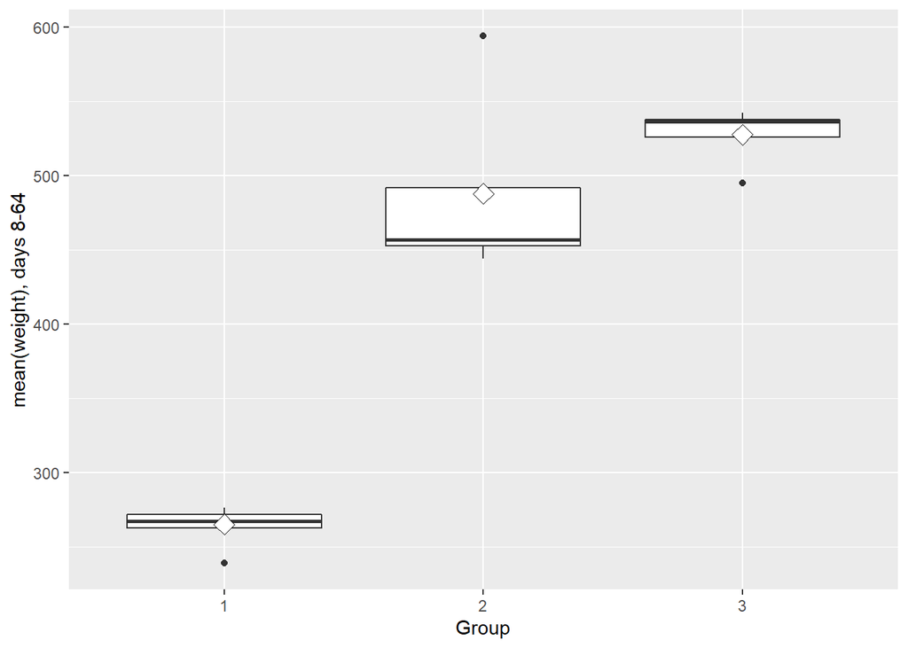

```r
library(dplyr)
library(tidyr)
library(ggplot2)
RATSL8S <- RATSL %>%
  filter(Time > 1) %>%
  group_by(Group, ID) %>%
  summarise( mean=mean(Weight) ) %>%
  ungroup()
ggplot(RATSL8S, aes(x = Group, y = mean)) +
  geom_boxplot() +
  stat_summary(fun.y = "mean", geom = "point", shape=23, size=4, fill = "white") +
  scale_y_continuous(name = "mean(weight), days 8-64")
```

There are outliers in the three groups. Let’s remove them from the dataset to better estimate further results.

## Removing outliers and graphing the boxplot again

```r
RATSL8S1 <- RATSL8S %>%
  filter(mean > 250 & mean < 550 & mean!= 495.2)
RATSL8S1 # We can check the value of the third mean outlier direclty from the dataset in group 3, it's 495.2.
```

```
## # A tibble: 13 x 3
##    Group ID     mean
##    <fct> <fct> <dbl>
##  1 1     1      263.
##  2 1     3      262.
##  3 1     4      267.
##  4 1     5      271.
##  5 1     6      276.
##  6 1     7      275.
##  7 1     8      268.
##  8 2     9      444.
##  9 2     10     458.
## 10 2     11     456.
## 11 3     14     536.
## 12 3     15     542.
## 13 3     16     536.
```

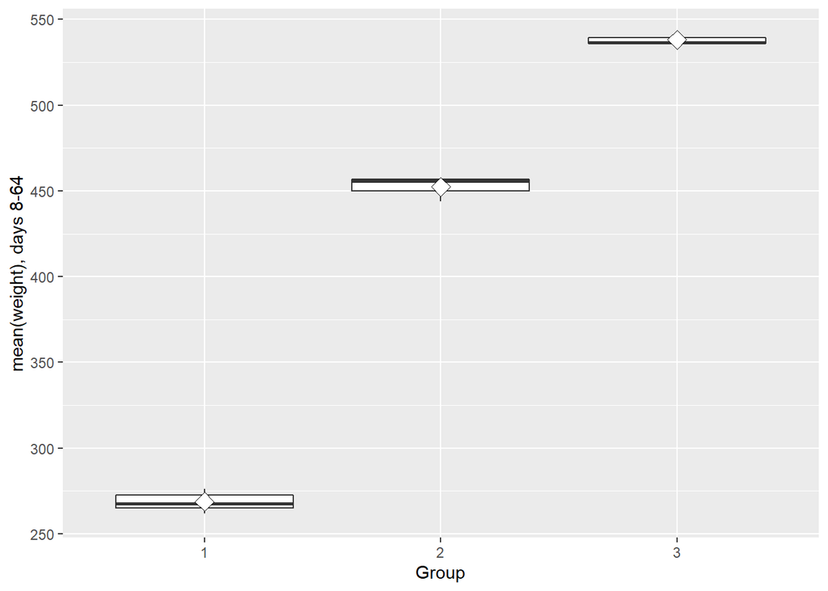

```r
ggplot(RATSL8S1, aes(x = Group, y = mean)) +
  geom_boxplot() +
  stat_summary(fun.y = "mean", geom = "point", shape=23, size=4, fill = "white") +
  scale_y_continuous(name = "mean(weight), days 8-64")
```

All the 3 outliers are removed.

## Assessing differences between intervention groups

```r
RATSL8S1
```

```
## # A tibble: 13 x 3
##    Group ID     mean
##    <fct> <fct> <dbl>
##  1 1     1      263.
##  2 1     3      262.
##  3 1     4      267.
##  4 1     5      271.
##  5 1     6      276.
##  6 1     7      275.
##  7 1     8      268.
##  8 2     9      444.
##  9 2     10     458.
## 10 2     11     456.
## 11 3     14     536.
## 12 3     15     542.
## 13 3     16     536.
```

```r
group1 <- RATSL8S1$mean[1:8]
group2 <- RATSL8S1$mean[9:11]
group3 <- RATSL8S1$mean[12:14]
t.test(group2, group3, data = RATSL8S1)
```

```
##
##  Welch Two Sample t-test
##
## data:  group2 and group3
## t = -2.0917, df = 2.0506, p-value = 0.1684
## alternative hypothesis: true difference in means is not equal to 0
## 95 percent confidence interval:
##  -168.41180   56.47847
## sample estimates:
## mean of x mean of y
##  483.2333  539.2000
```

```r
t.test(group1, group3, data = RATSL8S1)
```

```
##
##  Welch Two Sample t-test
##
## data:  group1 and group3
## t = -11.211, df = 7.2459, p-value = 7.738e-06
## alternative hypothesis: true difference in means is not equal to 0
## 95 percent confidence interval:
##  -300.6142 -196.4858
## sample estimates:
## mean of x mean of y
##    290.65    539.20
```

```r
t.test(group2, group1, data = RATSL8S1)
```

```
##
##  Welch Two Sample t-test
##
## data:  group2 and group1
## t = 5.5841, df = 4.9968, p-value = 0.002545
## alternative hypothesis: true difference in means is not equal to 0
## 95 percent confidence interval:
##  103.9124 281.2543
## sample estimates:
## mean of x mean of y
##  483.2333  290.6500
```

## Incorporating baseline measurments from day 1, fitting a linear model and performing an analysis of variance

```r
RATSL8S2 <- RATSL8S %>%
  mutate(baseline = RATS$WD1)
fit <- lm(mean ~ baseline + Group, data = RATSL8S2)
anova(fit)
```

```
## Analysis of Variance Table
##
## Response: mean
##           Df Sum Sq Mean Sq   F value   Pr(>F)
## baseline   1 253625  253625 1859.8201 1.57e-14 ***
## Group      2    879     439    3.2219  0.07586 .
## Residuals 12   1636     136
## ---
## Signif. codes:  0 '***' 0.001 '**' 0.01 '*' 0.05 '.' 0.1 ' ' 1
```

Baseline values of weight are strongly correlated with increased mean weight; however, there is no evidence that mean weight increased significantly.

## Checking if there is any missing value in RATS

```r
is.na(RATS)
```

[output not shown]

[output cut: 19 more lines]

There is no missing value in the dataset.

# PART II

## Reading the BPRS data

```r
setwd("C:/Users/Sara Allaouat/Documents/IODS-project/data")
BPRS <- read.table("BPRS.txt", header = TRUE, sep = "")
library(dplyr)
library(tidyr)
BPRS$treatment <- factor(BPRS$treatment)
BPRS$subject <- factor(BPRS$subject)
str(BPRS)
```

```
## 'data.frame':    40 obs. of  11 variables:
##  $ treatment: Factor w/ 2 levels "1","2": 1 1 1 1 1 1 1 1 1 1 ...
##  $ subject  : Factor w/ 20 levels "1","2","3","4",..: 1 2 3 4 5 6 7 8 9 10 ...
##  $ week0    : int  42 58 54 55 72 48 71 30 41 57 ...
##  $ week1    : int  36 68 55 77 75 43 61 36 43 51 ...
##  $ week2    : int  36 61 41 49 72 41 47 38 39 51 ...
##  $ week3    : int  43 55 38 54 65 38 30 38 35 55 ...
##  $ week4    : int  41 43 43 56 50 36 27 31 28 53 ...
##  $ week5    : int  40 34 28 50 39 29 40 26 22 43 ...
##  $ week6    : int  38 28 29 47 32 33 30 26 20 43 ...
##  $ week7    : int  47 28 25 42 38 27 31 25 23 39 ...
##  $ week8    : int  51 28 24 46 32 25 31 24 21 32 ...
```

```r
colnames(BPRS)
```

```
##  [1] "treatment" "subject"   "week0"     "week1"     "week2"
##  [6] "week3"     "week4"     "week5"     "week6"     "week7"
## [11] "week8"
```